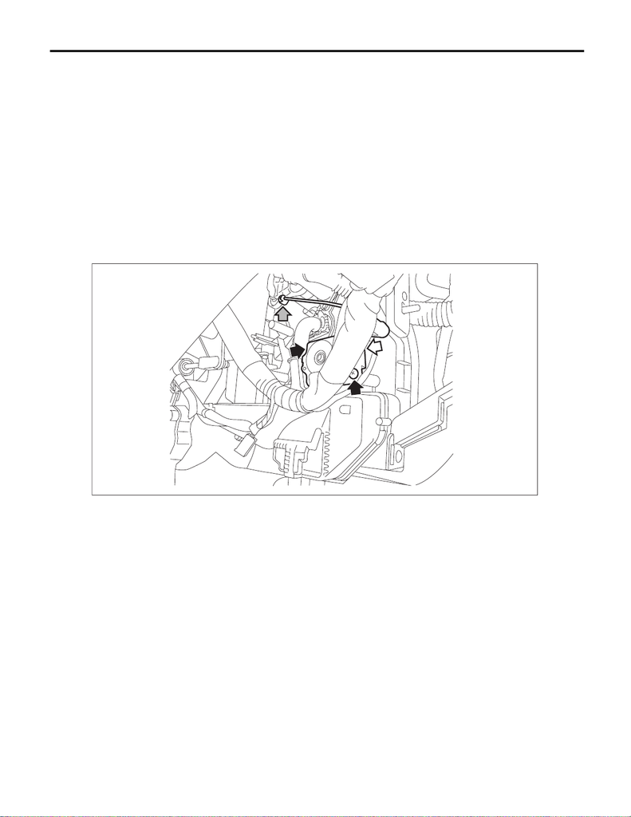

Mode Door Actuator

HVAC SYSTEM (HEATER, VENTILATOR AND A/C)

26.Mode Door Actuator

A: REMOVAL

CAUTION:

Before handling the airbag module, refer to “CAUTION” of “General Description” in “AIRBAG SYS-

TEM”. <Ref. to AB-9, CAUTION, General Description.>

1) Disconnect the battery ground cable and wait for at least 60 seconds before starting work. <Ref. to NT-5,

BATTERY, NOTE, Note.>

NOTE:

For models other than STI model, disconnect the ground terminal from battery sensor.

2) Remove the instrument panel lower cover. <Ref. to EI-61, REMOVAL, Instrument Panel Lower Cover.>

3) Remove the knee airbag module. <Ref. to AB-35, REMOVAL, Knee Airbag Module.>

4) Remove the motor - actuator mode.

(1) Disconnect the connector, and remove the rod from the rod clamp.

(2) Remove the screws and detach the motor - actuator mode.

B: INSTALLATION

CAUTION:

Before handling the airbag module, refer to “CAUTION” of “General Description” in “AIRBAG SYS-

TEM”. <Ref. to AB-9, CAUTION, General Description.>

1) Install the motor - actuator mode.

2) Install the knee airbag module.

Tightening torque:

7.5 N·m (0.8 kgf-m, 5.5 ft-lb)

3) Install the instrument panel lower cover.

4) Connect the battery ground terminal. <Ref. to NT-5, BATTERY, NOTE, Note.>

NOTE:

For models other than STI model, connect the ground terminal to battery sensor.

AC-02719

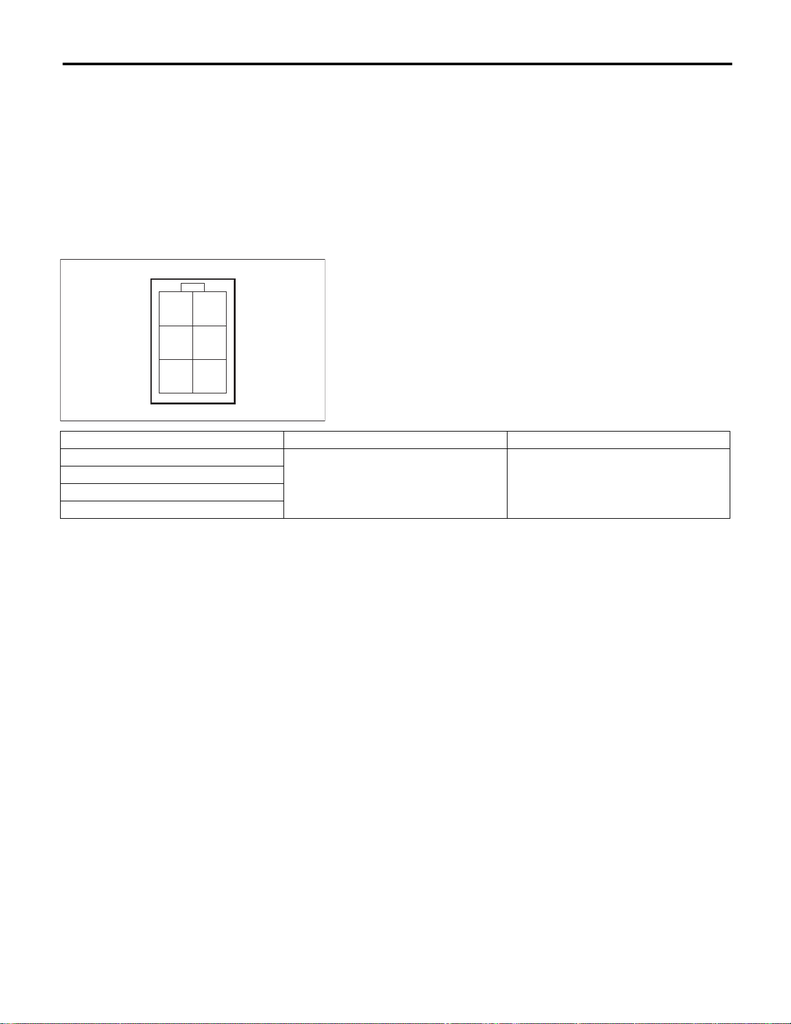

Mode Door Actuator

HVAC SYSTEM (HEATER, VENTILATOR AND A/C)

C: INSPECTION

1. CHECK LINK

1) Visually check the operation range of the link, and remove the foreign material if any.

2) Operate the air flow control dial or switch to check that the link operates normally.

3) If it does not operate normally as the result of inspection, check the motor - actuator mode.

2. CHECK ACTUATOR

1) Measure the resistance between connector terminals.

Preparation tool:

Circuit tester

2) Replace the motor - actuator mode if it is found defective as a result of inspection.

AC-03547

Terminal No. Inspection conditions Standard

3 — 1

Always 80 — 100 Ω

3 — 2

3 — 5

3 — 6